# Teil 2: Graphiken

Andreas Mock

Nationales Centrum für Tumorerkrankungen (NCT) Heidelberg  
andreas.mock@med.uni-heidelberg.de

## Einführung

Obwohl *R* fast alle Funktionaliäten der modernen Datenanalyse in der biomedizinischen Forschung bietet, benutzen viele Wissenschaftler *R* ausschließlich, um maßgeschneiderte Abbildung für Publikationen etc. zu erstellen.

## Base graphics

“Out of the box” bietet *R*, die sogenannten *base graphics*, die ohne die Installation eines weiteren Paketes nutzbar sind. Die wichtigste Funktionen sind hierbei `plot`, `hist`, `barplot` und`boxplot`, die eine Reihe von Objekten automatisch erkennen und entsprechend Visualisierungen erstellen. Mithilfe der Funktion `par` können zudem die Graphikparameter angepasst (z.B. 4 Subplots mit dem Argument `mfrow`).

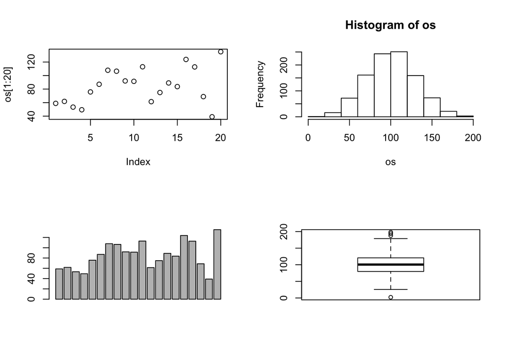

```r
# draw random overall survival (days)
os <- rnorm(n=1000,
           mean=100,
           sd = 30)

par(mfrow=c(2,2))
plot(os[1:20])
hist(os)
barplot(os[1:20])
boxplot(os)
```

Der Vorsteil der *Base graphics* Funktionen ist, dass sie leicht anzuwenden und zu erlernen sind und dass sie mit einigen wenigen Einstellungen ansprechend gestaltet werden können:

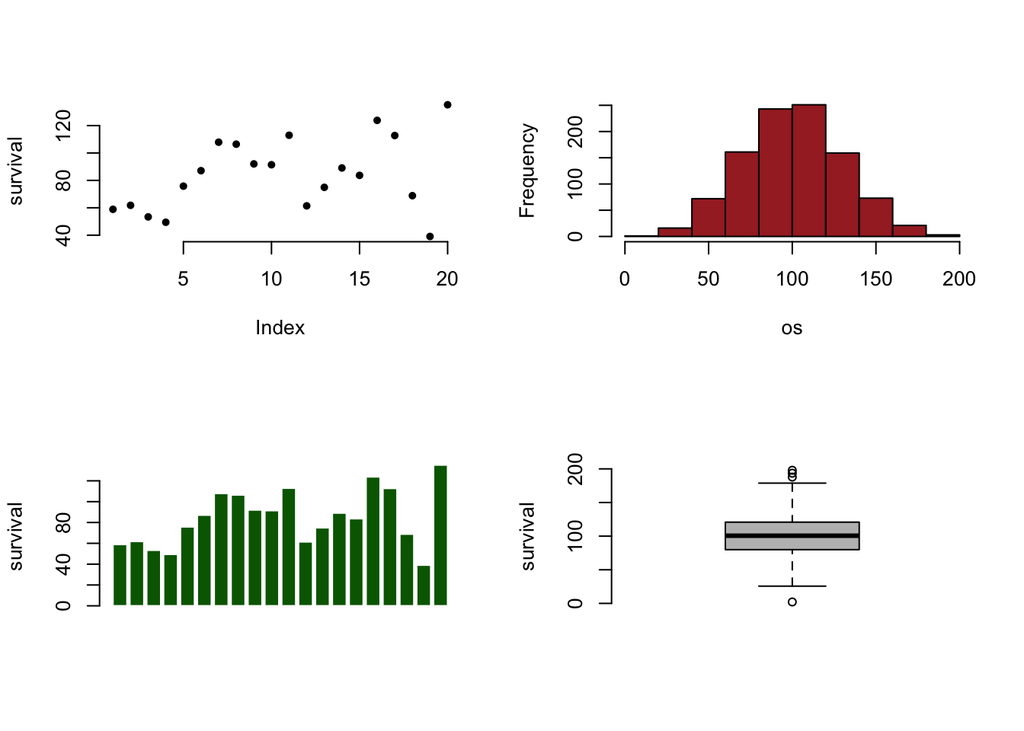

```r
par(mfrow=c(2,2))
plot(os[1:20], bty="n", pch=20, ylab="survival")
hist(os, breaks=10, col="brown", main="")
barplot(os[1:20], border = "white", col="darkgreen", ylab="survival")
boxplot(os, frame=FALSE, ylab="survival", col="grey")
```

## ggplot2

Gilt es mehere Daten miteinander in Beziehung zu setzen und Assoziationen zu eruieren werden die *base graphics* Funktionen jedoch schnell umständlich. So hat sich in den letzten Jahren in weiten Teilen der Datenvisualisierung mit *R* die Syntax des so genannten `ggplot2` Pakets durchgesetzt. Auch wenn es didaktisch nicht ideal sein mag, soll im Folgenden auch die Funktionsweise von Plots mit dem `ggplot2` Pakets präsentiert werden, da sich mit Hilfe von `ggplot2` viele Datenumformattierungen umgehen lassen und so der Fokus auf der Datenexplorarion liegen kann.

Die Grundfunktion lautet `ggplot`. Wie auch schon in *base graphics* ist das erste Argument der Funktion das Objekt welches wir Visualisieren wollen, im Falle von `ggplot` einen *dataframe*:

```r
# Paket ggplot2 installieren
install.packages("ggplot2")
library(ggplot2)
```

```r
df <- data.frame(survival = rnorm(n=1000,mean=100,sd = 30),
                grade=sample(x = c("G1","G2","G3"),
                             size = 1000, replace = TRUE,prob = c(3,2,1)),
                age=rnorm(n=1000,50,sd=30))
```

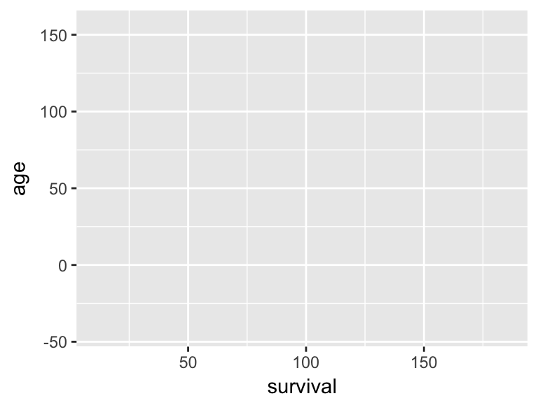

```r
ggplot(df, aes(x=survival, y=age))
```

### Dot plot

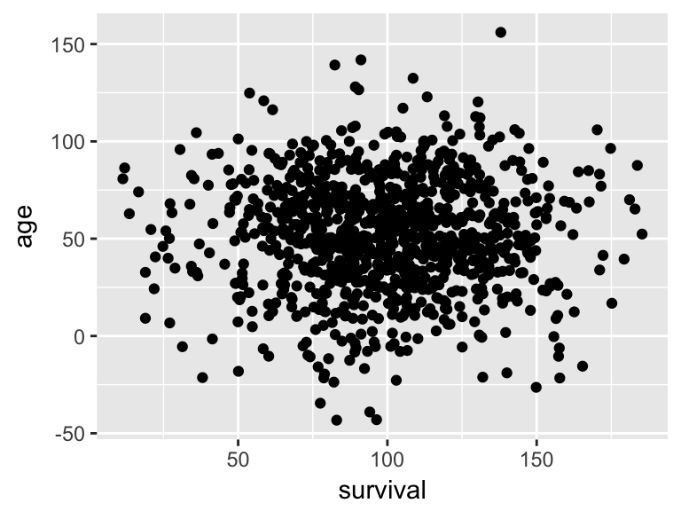

```r
ggplot(df, aes(x=survival, y=age)) +
    geom_point()
```

### Boxplot

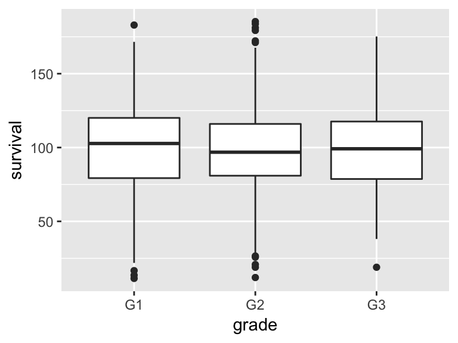

```r
ggplot(df, aes(x=grade, y=survival)) +
    geom_boxplot()
```

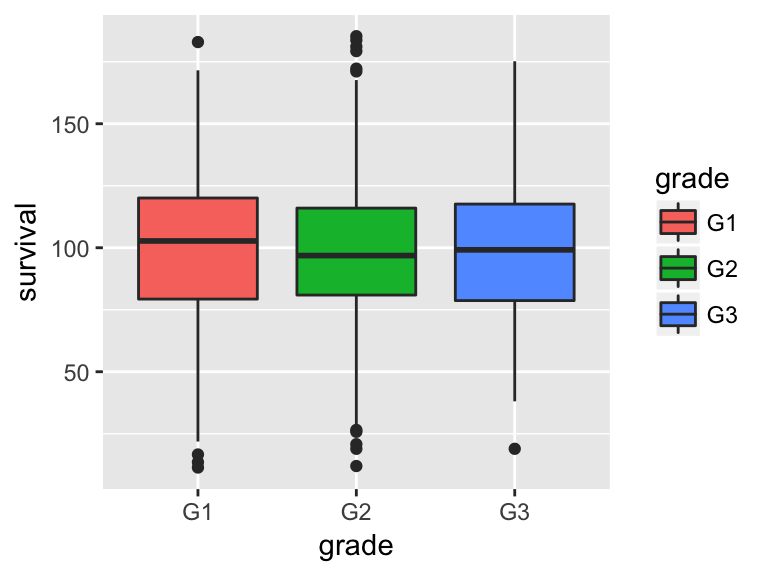

```r
ggplot(df, aes(x=grade, y=survival, fill=grade)) +
    geom_boxplot()
```

### Histogramm

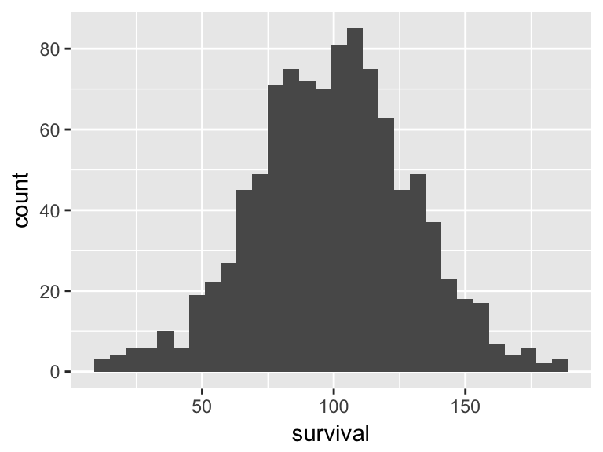

```r
ggplot(df, aes(x=survival)) +
    geom_histogram()
```

### Density plot

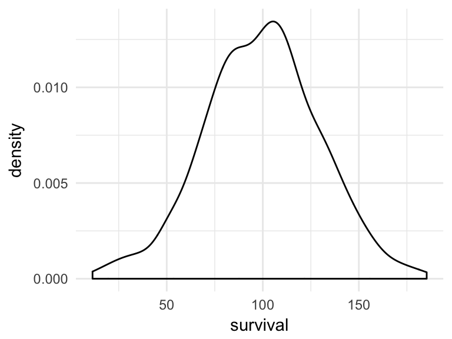

```r
ggplot(df, aes(x=survival)) +
    geom_density() +
    theme_minimal()
```

### 2D Density plot

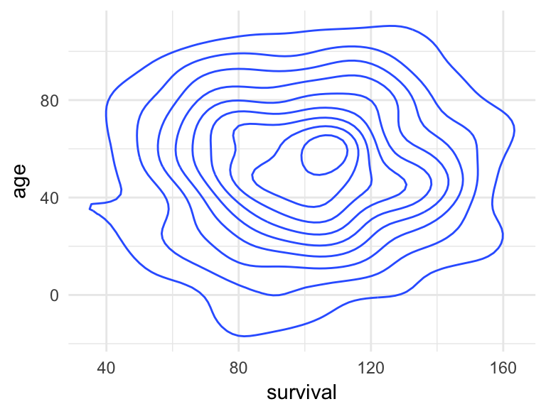

```r
ggplot(df, aes(x=survival, y=age)) +
    geom_density2d() +
    theme_minimal()
```

Mehr Informationen zu den Funktionalitäten von `ggplot` finden sich auf der [Entwicklerhomepage](http://ggplot2.tidyverse.org).

## Beispieldaten

**Integrated Genomic Characterization of Pancreatic Ductal Adenocarcinoma**  
*Cancer Cell*. **Volume 32** Issue 2: p185-203

```r
# Packet gdata installieren
install.packages("gdata")
library(gdata)
```

```r
padc = read.xls(xls="http://www.cell.com/cms/attachment/2106066377/2081438868/mmc2.xlsx",
                skip=1)
```

## Übung (ca. 30 min.)

Nutzt die oben aufgeführten Funktionen zur Visualisierung der Pankreasmetadaten

Als Startpunkt:

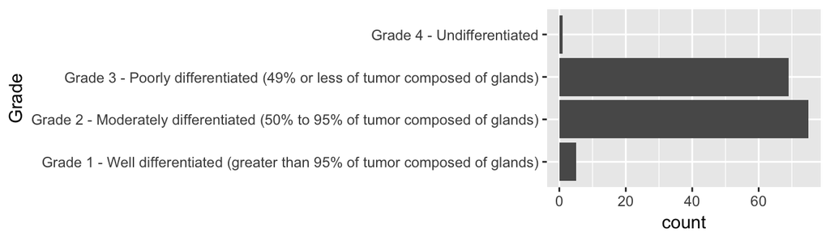

```r
ggplot(padc, aes(x=Grade)) +
    geom_bar() +
    coord_flip()
```